# Best books by century

Marian Nehrebecki, Aleksander Partyga, Magdalena Sobala

07 June, 2022

## **Century 12**

### Overview

(From the [Goodreads](https://www.goodreads.com)) Goodreads.com is the world’s largest site for readers and book recommendations. The mission of Goodreads is to help people find and share books they love.

The users can rate their favourite books, create lists and share their opinions with their friends. The website also provides extensive information on books from all genres and centuries; it also provides the users with rankings, available by different parameters. The rankings that are of interest to us, are the rating by the century. Below you can find a short summary of each century’s best books.

### A few things we can do on Goodreads

> - See what books our friends are reading.
> - Track the books we are reading, have read, and want to read.
> - Check out our personalized book recommendations. The recommendation engine analyzes 20 billion data points to give suggestions tailored to our literary tastes.
> - Find out if a book is a good fit for us from our community’s reviews.

# Summary of the Best books in Century 12

*Goodreads* provides its users with information on 61 books from **Century 12** that have been published by Author/Authors from **Geoffrey of Monmouth** to **Bernard de Ventadour**.

The best book in Century 12 was **The History of the Kings of Britain** by **Geoffrey of Monmouth** which gathered *30 votes*, *2960 scores* and an average rating of *4.5*.

The book can be found under the following link: “https://www.goodreads.com/book/show/129521.The_History_of_the_Kings_of_Britain”

## Visualisations:

### Books that were rated the most times in Century 12

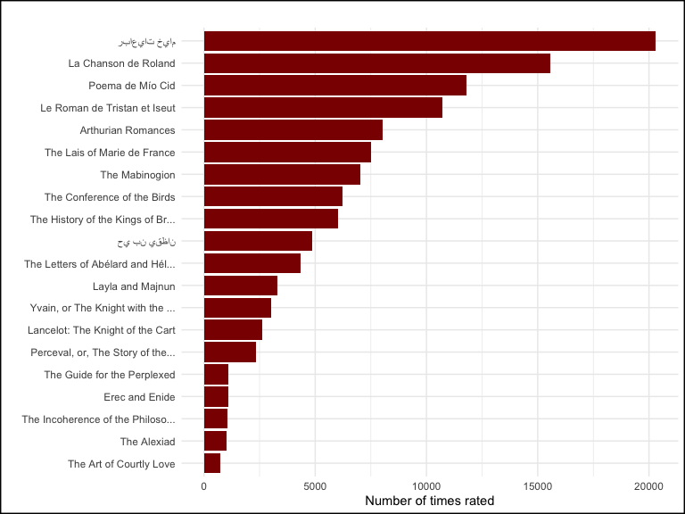

**Summary:**

- The book that was rated the most in Century 12 is **رباعيات خيام**, and the number of votes is **20310**.
- The average number of voted for a book from Century 12 is equal **2076.8**.

### Books with the highest scores in Century 12

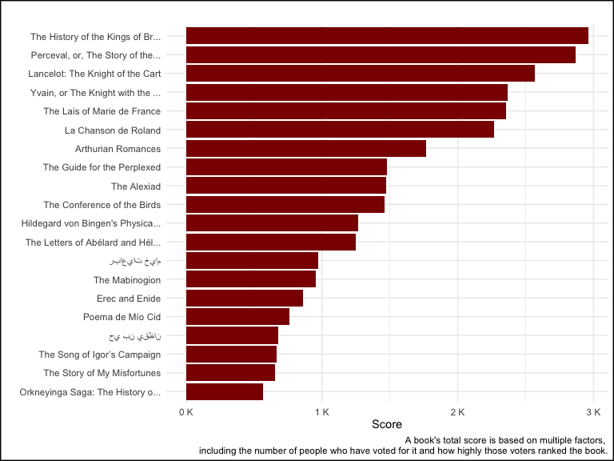

**Summary:**

- The maximum score for a book in Century 12 is **2960** for the book: **The History of the Kings of Britain**.
- The average score of all books in Century 12 is **628.3**.
- The minimum score for a book in Century 12 is **58** for the book: **Chansons d’amour de Bernart de Ventadorn**.

### Most prolific authors in Century 12

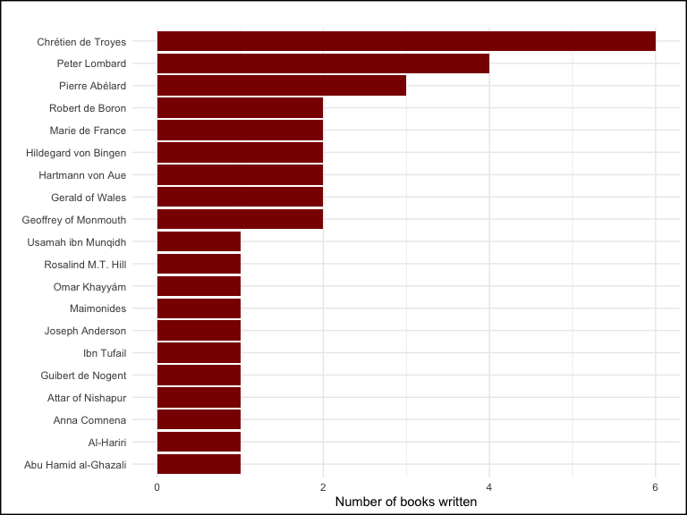

**Summary:**

- The most prolific author in Century 12 is **Chrétien de Troyes**.

## List of books with above average rating in Century 12

The number of books with the above average rating in Century 12 is **36** out of all **61** Century 12 books. The below table displays the top 10 results.

| Century | Title | Author | website |
| --- | --- | --- | --- |
| 12th | The Guide for the Perplexed | Maimonides | https://www.goodreads.com/book/show/761925.The_Guide_for_the_Perplexed |
| 12th | رباعيات خيام | Omar Khayyám | https://www.goodreads.com/book/show/716696._ |
| 12th | حي بن يقظان | Ibn Tufail | https://www.goodreads.com/book/show/6646964 |
| 12th | Layla and Majnun | Nizami Ganjavi | https://www.goodreads.com/book/show/67397.Layla_and_Majnun |
| 12th | Incoherence of the Incoherence | Ibn Rushd | https://www.goodreads.com/book/show/8152334-incoherence-of-the-incoherence |
| 12th | The Sentences Book 4: On The Doctrine of Signs | Peter Lombard | https://www.goodreads.com/book/show/6512045-the-sentences-book-4 |
| 12th | The Journey Through Wales & The Description of Wales | Gerald of Wales | https://www.goodreads.com/book/show/721083.The_Journey_Through_Wales_The_Description_of_Wales |
| 12th | The Metalogicon: A Twelfth-Century Defense of the Verbal and Logical Arts of the Trivium | John Salisbury | https://www.goodreads.com/book/show/7674855-the-metalogicon |
| 12th | The Book of Beasts: Being a Translation from a Latin Bestiary of the 12th Century | T.H. White | https://www.goodreads.com/book/show/821861.The_Book_of_Beasts |
| 12th | The Kuzari: An Argument for the Faith of Israel | Yehuda HaLevi | https://www.goodreads.com/book/show/892265.The_Kuzari |

### References:

https://www.goodreads.com